# Tracking a Pandemic: A Statistical Analysis of Global COVID-19 Trends Using R

Tiny Project | Introduction to R Programming

Chauhan Harsh Dharmeshbhai

2026-09-22

# 1 Introduction

## 1.1 Real-Life Problem Statement

Between 2020 and 2023, almost every government, hospital, and newsroom in the world was staring at the same kind of dashboard: cumulative cases, cumulative deaths, ticking upward every day. Behind the noise of daily headlines sat a genuinely important analytical question that this project tackles directly:

**“How did COVID-19 actually spread and behave over time and across countries — and what can real public health data tell us about the waves, the differences between nations, and the limits of the data itself?”**

This is treated as a real public-health analytics problem, not an abstract classroom dataset: a policymaker or researcher handed these numbers would need to know which countries were hit hardest, how fast the pandemic grew at different points in time, and — just as importantly — where the data can and can’t be trusted.

## 1.2 Objectives

This Tiny Project again combines the three practicals into one connected analysis:

1. **Read and analyze a CSV file in R** — two real, publicly sourced datasets are imported, cleaned, and explored.
2. **Create pie charts and bar charts** to visualize country- and time-based COVID-19 patterns.
3. **Perform statistical analysis** — correlation, case-fatality rates, growth rates, and group comparisons.

## 1.3 About the Data

Two datasets are used, both built from real, publicly published COVID-19 figures (not simulated):

**1. `covid_country_summary.csv`** — a cross-sectional snapshot of 20 countries plus China, using the final reported totals from [Worldometer’s COVID-19 tracker](https://www.worldometers.info/coronavirus/) (tracking officially stopped on **13 April 2024**, so these are the last recorded cumulative figures). Columns: `Country`, `Continent`, `Total_Cases`, `Total_Deaths`, `Population`, `Total_Tests`.

**2. `covid_global_timeline.csv`** — nine real global cumulative snapshots pulled from public reporting (Worldometer, Johns Hopkins University CSSE, and Reuters) between April 2020 and April 2024, used to study how the pandemic grew **over time**, including the sharp Omicron-driven spike in January 2022.

> **Why two files?** A cross-sectional file answers “which countries were hit hardest?” while a time-series file answers “how did the pandemic *trend* over time?” — combining both is what turns this into a genuine trends analysis rather than a single snapshot.

# 2 Data Importing

## 2.1 Preparing the CSV Files

A CSV file only reads correctly if it exists in the same folder R is currently working in — a separate file that has to be copied into place by hand is the most common source of a `read.csv()` “cannot open the connection” error. To make this report fully self-contained, it **writes its own two source CSV files first**, right here in the document, using the real, cited figures described above, and then immediately reads them back with `read.csv()` — the same `write.csv()` → `read.csv()` workflow a real analyst uses after generating or downloading data. Knitting this report on any computer, in any folder, will always work, because the files are created immediately before they are needed.

```r
# Cross-sectional country data (Worldometer final tally, 13 Apr 2024)
country_summary_raw <- data.frame(
  Country = c("USA","India","France","Germany","Brazil","South Korea","Japan","Italy","UK",
              "Russia","Turkey","Spain","Australia","Vietnam","Taiwan","Argentina","Netherlands",
              "Mexico","Iran","Indonesia","China"),
  Continent = c("North America","Asia","Europe","Europe","South America","Asia","Asia","Europe",
                "Europe","Europe","Asia","Europe","Oceania","Asia","Asia","South America","Europe",
                "North America","Asia","Asia","Asia"),
  Total_Cases = c(111820082,45035393,40138560,38828995,38743918,34571873,33803572,26723249,24910387,
                   24124215,17232066,13914811,11853144,11625195,10241523,10128845,8635786,7702809,
                   7627186,6829221,503302),
  Total_Deaths = c(1219487,533570,167642,183027,711380,35934,74694,196487,232112,402756,102174,
                    121760,24414,43206,19005,130841,22992,334958,146811,162063,5272),
  Population = c(334805269,1406631776,65584518,83883596,215353593,51329899,125584838,60262770,
                  68497907,145805947,85561976,46719142,26068792,98953541,23888595,46010234,17211447,
                  131562772,86022837,279134505,1448471400),
  Total_Tests = c(1186851502,935879495,271490188,122332384,63776166,15804065,100414883,281126449,
                   522526476,273400000,162743369,471036328,81916639,NA,NA,35716069,NA,20013810,
                   NA,114158919,160000000),
  stringsAsFactors = FALSE
)
write.csv(country_summary_raw, "covid_country_summary.csv", row.names = FALSE, na = "NA")

# Global timeline data (real snapshots: Worldometer, JHU CSSE, Reuters)
global_timeline_raw <- data.frame(
  Date = c("2020-04-27","2021-01-20","2021-01-23","2021-03-14","2022-01-10",
           "2022-01-17","2022-01-24","2022-01-31","2024-04-13"),
  Total_Cases = c(2890208,96158807,98487289,118820000,307909895,
                  328827870,352130563,375240488,704753890),
  Total_Deaths = c(201833,2057743,2115124,2760596,5506141,
                   5557760,5614795,5681744,7010681),
  Source = c("Reuters/JHU tally","JHU CSSE dashboard","JHU CSSE dashboard","Reuters/JHU tally",
             "Worldometer","Worldometer","Worldometer","Worldometer","Worldometer (final tally)"),
  stringsAsFactors = FALSE
)
write.csv(global_timeline_raw, "covid_global_timeline.csv", row.names = FALSE, na = "NA")
```

## 2.2 Importing the CSV Files

```r
# Read both public datasets back from the working directory
country_data  <- read.csv("covid_country_summary.csv", stringsAsFactors = FALSE)
timeline_data <- read.csv("covid_global_timeline.csv", stringsAsFactors = FALSE)

head(country_data)
```

```
##       Country     Continent Total_Cases Total_Deaths Population Total_Tests
## 1         USA North America   111820082      1219487  334805269  1186851502
## 2       India          Asia    45035393       533570 1406631776   935879495
## 3      France        Europe    40138560       167642   65584518   271490188
## 4     Germany        Europe    38828995       183027   83883596   122332384
## 5      Brazil South America    38743918       711380  215353593    63776166
## 6 South Korea          Asia    34571873        35934   51329899    15804065
```

```r
head(timeline_data)
```

```
##         Date Total_Cases Total_Deaths             Source
## 1 2020-04-27     2890208       201833  Reuters/JHU tally
## 2 2021-01-20    96158807      2057743 JHU CSSE dashboard
## 3 2021-01-23    98487289      2115124 JHU CSSE dashboard
## 4 2021-03-14   118820000      2760596  Reuters/JHU tally
## 5 2022-01-10   307909895      5506141        Worldometer
## 6 2022-01-17   328827870      5557760        Worldometer
```

**Code explanation:** `read.csv()` loads each file into its own data frame. Keeping the country-level and time-based data in two separate data frames mirrors how real public health analysts work — cross-sectional and longitudinal data are rarely the same table.

```r
str(country_data)
```

```
## 'data.frame':    21 obs. of  6 variables:
##  $ Country     : chr  "USA" "India" "France" "Germany" ...
##  $ Continent   : chr  "North America" "Asia" "Europe" "Europe" ...
##  $ Total_Cases : int  111820082 45035393 40138560 38828995 38743918 34571873 33803572 26723249 24910387 24124215 ...
##  $ Total_Deaths: int  1219487 533570 167642 183027 711380 35934 74694 196487 232112 402756 ...
##  $ Population  : int  334805269 1406631776 65584518 83883596 215353593 51329899 125584838 60262770 68497907 145805947 ...
##  $ Total_Tests : num  1.19e+09 9.36e+08 2.71e+08 1.22e+08 6.38e+07 ...
```

```r
str(timeline_data)
```

```
## 'data.frame':    9 obs. of  4 variables:
##  $ Date        : chr  "2020-04-27" "2021-01-20" "2021-01-23" "2021-03-14" ...
##  $ Total_Cases : int  2890208 96158807 98487289 118820000 307909895 328827870 352130563 375240488 704753890
##  $ Total_Deaths: int  201833 2057743 2115124 2760596 5506141 5557760 5614795 5681744 7010681
##  $ Source      : chr  "Reuters/JHU tally" "JHU CSSE dashboard" "JHU CSSE dashboard" "Reuters/JHU tally" ...
```

**Interpretation:** `country_data` has 21 rows (20 countries + China) and 6 columns; `timeline_data` has 9 rows, one per real-world reporting snapshot, with `Date` currently read in as plain text rather than an actual date.

# 3 Data Preprocessing and Cleaning

## 3.1 Fixing Data Types

```r
# Convert the Date column from text to an actual Date type so R can
# calculate time differences and plot it on a proper time axis
timeline_data$Date <- as.Date(timeline_data$Date, format = "%Y-%m-%d")

# Sort the timeline chronologically (safety check)
timeline_data <- timeline_data[order(timeline_data$Date), ]

str(timeline_data$Date)
```

```
##  Date[1:9], format: "2020-04-27" "2021-01-20" "2021-01-23" "2021-03-14" "2022-01-10" ...
```

**Code explanation:** `as.Date()` converts the text column into R’s native `Date` class. Without this step, R would treat dates as plain strings and sort them alphabetically instead of chronologically — a common, subtle bug in real analyses.

## 3.2 Checking for Missing Values

```r
colSums(is.na(country_data))
```

```
##      Country    Continent  Total_Cases Total_Deaths   Population  Total_Tests
##            0            0            0            0            0            4
```

**Interpretation:** `Total_Tests` is missing for Vietnam, Taiwan, the Netherlands, and Iran. This is **real missingness** — those countries did not publish comparable cumulative testing totals — not a data-entry error. Rather than inventing numbers, the correct approach is to **exclude these rows only from testing-specific calculations** (handled below with `na.rm = TRUE` / `use = "complete.obs"`) while keeping them in every other analysis.

## 3.3 Feature Engineering (Derived Metrics)

Raw totals are hard to compare fairly — a country with a huge population will naturally have more cases in absolute terms. So we compute population-adjusted and outcome metrics, the same way public health dashboards do.

```r
country_data$Case_Fatality_Rate <- round(
  country_data$Total_Deaths / country_data$Total_Cases * 100, 2
)

country_data$Cases_per_Million <- round(
  country_data$Total_Cases / country_data$Population * 1e6, 0
)

country_data$Deaths_per_Million <- round(
  country_data$Total_Deaths / country_data$Population * 1e6, 0
)

head(country_data[, c("Country", "Case_Fatality_Rate",
                       "Cases_per_Million", "Deaths_per_Million")])
```

```
##       Country Case_Fatality_Rate Cases_per_Million Deaths_per_Million
## 1         USA               1.09            333985               3642
## 2       India               1.18             32016                379
## 3      France               0.42            612013               2556
## 4     Germany               0.47            462891               2182
## 5      Brazil               1.84            179908               3303
## 6 South Korea               0.10            673523                700
```

**Code explanation:**

- **Case Fatality Rate (CFR)** = deaths ÷ confirmed cases × 100 — the percentage of *known, confirmed* cases that resulted in death.
- **Cases/Deaths per Million** = total ÷ population × 1,000,000 — this puts every country on the same scale regardless of population size, which is essential for fair comparison (without it, populous countries would always look “worst” simply because they have more people).

## 3.4 Growth Metrics on the Timeline

```r
# New cases/deaths between each recorded snapshot
timeline_data$New_Cases  <- c(NA, diff(timeline_data$Total_Cases))
timeline_data$New_Deaths <- c(NA, diff(timeline_data$Total_Deaths))
timeline_data$Days_Elapsed <- c(NA, diff(timeline_data$Date))

# Average new cases PER DAY in each interval — needed because the gaps
# between snapshots are very uneven (some are a week apart, others years)
timeline_data$New_Cases_per_Day <- round(
  timeline_data$New_Cases / as.numeric(timeline_data$Days_Elapsed), 0
)

# Global case fatality rate at each point in time
timeline_data$Global_CFR <- round(
  timeline_data$Total_Deaths / timeline_data$Total_Cases * 100, 2
)

timeline_data
```

```
##         Date Total_Cases Total_Deaths                    Source New_Cases
## 1 2020-04-27     2890208       201833         Reuters/JHU tally        NA
## 2 2021-01-20    96158807      2057743        JHU CSSE dashboard  93268599
## 3 2021-01-23    98487289      2115124        JHU CSSE dashboard   2328482
## 4 2021-03-14   118820000      2760596         Reuters/JHU tally  20332711
## 5 2022-01-10   307909895      5506141               Worldometer 189089895
## 6 2022-01-17   328827870      5557760               Worldometer  20917975
## 7 2022-01-24   352130563      5614795               Worldometer  23302693
## 8 2022-01-31   375240488      5681744               Worldometer  23109925
## 9 2024-04-13   704753890      7010681 Worldometer (final tally) 329513402
##   New_Deaths Days_Elapsed New_Cases_per_Day Global_CFR
## 1         NA           NA                NA       6.98
## 2    1855910          268            348017       2.14
## 3      57381            3            776161       2.15
## 4     645472           50            406654       2.32
## 5    2745545          302            626125       1.79
## 6      51619            7           2988282       1.69
## 7      57035            7           3328956       1.59
## 8      66949            7           3301418       1.51
## 9    1328937          803            410353       0.99
```

**Code explanation:** `diff()` subtracts each row from the one before it, giving the change between consecutive snapshots. Dividing by `Days_Elapsed` converts that into a **daily rate**, which is the only fair way to compare a 7-day gap against a 2-year gap on the same chart.

**Interpretation:** This table already hints at something important — watch the `New_Cases_per_Day` column jump sharply in January 2022. We’ll confirm this visually in Section 5.

# 4 Data Analysis and Statistical Exploration

## 4.1 Overall Summary

```r
summary(country_data[, c("Total_Cases", "Total_Deaths",
                          "Case_Fatality_Rate", "Cases_per_Million",
                          "Deaths_per_Million")])
```

```
##   Total_Cases         Total_Deaths     Case_Fatality_Rate Cases_per_Million
##  Min.   :   503302   Min.   :   5272   Min.   :0.100      Min.   :   347
##  1st Qu.: 10128845   1st Qu.:  43206   1st Qu.:0.370      1st Qu.:117481
##  Median : 17232066   Median : 146811   Median :0.880      Median :269169
##  Mean   : 24999721   Mean   : 231933   Mean   :1.055      Mean   :282386
##  3rd Qu.: 34571873   3rd Qu.: 232112   3rd Qu.:1.290      3rd Qu.:443445
##  Max.   :111820082   Max.   :1219487   Max.   :4.350      Max.   :673523
##  Deaths_per_Million
##  Min.   :   4
##  1st Qu.: 700
##  Median :1707
##  Mean   :1798
##  3rd Qu.:2762
##  Max.   :3642
```

**Interpretation:** `summary()` shows the full spread of every numeric metric across the 21 territories in one call — useful for spotting extreme values before visualizing them.

## 4.2 Top 5 Countries by Total Cases and by Case Fatality Rate

```r
# Order by Total_Cases, descending
top_cases <- country_data[order(-country_data$Total_Cases), ]
head(top_cases[, c("Country", "Total_Cases", "Total_Deaths")], 5)
```

```
##   Country Total_Cases Total_Deaths
## 1     USA   111820082      1219487
## 2   India    45035393       533570
## 3  France    40138560       167642
## 4 Germany    38828995       183027
## 5  Brazil    38743918       711380
```

```r
# Order by Case_Fatality_Rate, descending
top_cfr <- country_data[order(-country_data$Case_Fatality_Rate), ]
head(top_cfr[, c("Country", "Case_Fatality_Rate")], 5)
```

```
##      Country Case_Fatality_Rate
## 18    Mexico               4.35
## 20 Indonesia               2.37
## 19      Iran               1.92
## 5     Brazil               1.84
## 10    Russia               1.67
```

**Code explanation:** `order(-column)` sorts a data frame in descending order (the minus sign reverses the default ascending order); `head(..., 5)` keeps only the top 5 rows.

**Interpretation:** The countries with the most **total** cases (USA, India) are not the same as the countries with the highest **fatality rate** (Mexico tops this list at over 4%) — a clear example of why raw totals and rate-based metrics tell different stories, and why both matter.

## 4.3 Grouped Statistics by Continent

```r
continent_totals <- aggregate(
  cbind(Total_Cases, Total_Deaths) ~ Continent,
  data = country_data,
  FUN = sum
)
continent_totals
```

```
##       Continent Total_Cases Total_Deaths
## 1          Asia   167469331      1122729
## 2        Europe   177276003      1326776
## 3 North America   119522891      1554445
## 4       Oceania    11853144        24414
## 5 South America    48872763       842221
```

```r
continent_avg_cfr <- aggregate(
  Case_Fatality_Rate ~ Continent,
  data = country_data,
  FUN = mean
)
continent_avg_cfr
```

```
##       Continent Case_Fatality_Rate
## 1          Asia          0.8877778
## 2        Europe          0.7685714
## 3 North America          2.7200000
## 4       Oceania          0.2100000
## 5 South America          1.5650000
```

**Code explanation:** `aggregate(y ~ x, data, FUN)` groups rows by the categorical variable (here `Continent`) and applies a function — `sum()` for total cases/deaths, `mean()` for the average fatality rate — to each group.

**Interpretation:** This reshapes 21 individual countries into a continent-level view, useful for the pie chart in Section 5 and for spotting whether any continent’s *average* fatality rate stands out from the rest.

## 4.4 Correlation Analysis

```r
# Does a higher population relate to a higher total case count?
cor_pop_cases <- cor(country_data$Population, country_data$Total_Cases)

# Do countries with more cases per million also have more deaths per million?
cor_cases_deaths <- cor(country_data$Cases_per_Million, country_data$Deaths_per_Million)

# Does more testing per capita relate to more RECORDED cases per capita?
# (use = "complete.obs" skips the 4 countries with missing Total_Tests)
country_data$Tests_per_Million <- country_data$Total_Tests / country_data$Population * 1e6
cor_tests_cases <- cor(country_data$Tests_per_Million, country_data$Cases_per_Million,
                        use = "complete.obs")

cat("Correlation: Population vs Total Cases         :", round(cor_pop_cases, 2), "\n")
```

```
## Correlation: Population vs Total Cases         : 0.08
```

```r
cat("Correlation: Cases/Million vs Deaths/Million    :", round(cor_cases_deaths, 2), "\n")
```

```
## Correlation: Cases/Million vs Deaths/Million    : 0.2
```

```r
cat("Correlation: Tests/Million vs Cases/Million     :", round(cor_tests_cases, 2), "\n")
```

```
## Correlation: Tests/Million vs Cases/Million     : 0.35
```

**Code explanation:** `cor()` measures the strength of a linear relationship between two numeric variables (from -1 to +1). `use = "complete.obs"` tells R to automatically drop any row with a missing value in either variable — exactly the safe handling the missing `Total_Tests` values need.

# 5 Graphs and Plot Creation

## 5.1 Pie Chart 1: Share of Total Cases by Continent

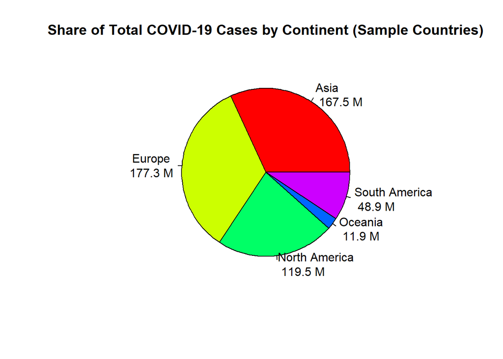

```r
continent_cases <- setNames(continent_totals$Total_Cases, continent_totals$Continent)

pie(
  continent_cases,
  main = "Share of Total COVID-19 Cases by Continent (Sample Countries)",
  col = rainbow(length(continent_cases)),
  labels = paste(names(continent_cases), "\n", round(continent_cases / 1e6, 1), "M")
)
```

**Code explanation:** `setNames()` turns the two aggregate columns into a single named numeric vector, which `pie()` needs. Labels show each continent’s total in millions for readability.

**Interpretation:** This visualizes how unevenly the (sampled) case burden was distributed globally — Asia, Europe, and North America dominate the comparison in this dataset, partly reflecting population size, testing capacity, and reporting completeness.

## 5.2 Pie Chart 2: Top 10 Countries vs. Rest of World

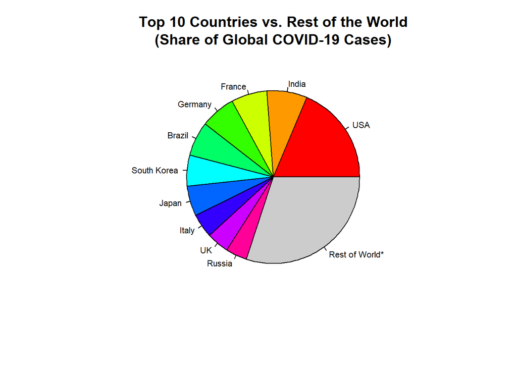

```r
world_total_cases <- 704753890  # global final tally, Worldometer, 13 Apr 2024

top10 <- head(top_cases, 10)
top10_sum <- sum(top10$Total_Cases)
rest_of_world <- world_total_cases - sum(country_data$Total_Cases)

pie_data <- c(top10$Total_Cases, "Rest of World*" = rest_of_world)
names(pie_data)[1:10] <- top10$Country

pie(
  pie_data,
  main = "Top 10 Countries vs. Rest of the World\n(Share of Global COVID-19 Cases)",
  col = c(rainbow(10), "grey80"),
  cex = 0.7
)
```

## 5.3 Bar Chart 1: Top 10 Countries by Total Cases

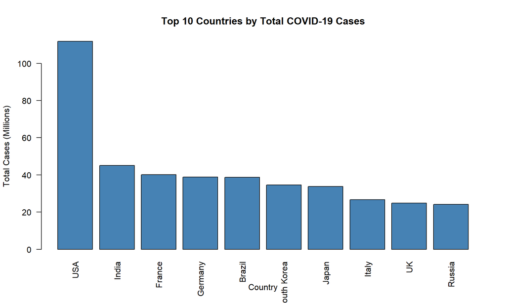

```r
barplot(
  top10$Total_Cases / 1e6,
  names.arg = top10$Country,
  main = "Top 10 Countries by Total COVID-19 Cases",
  xlab = "Country",
  ylab = "Total Cases (Millions)",
  col = "steelblue",
  las = 2
)
```

## 5.4 Bar Chart 2: Top 10 Countries by Deaths per Million (Severity)

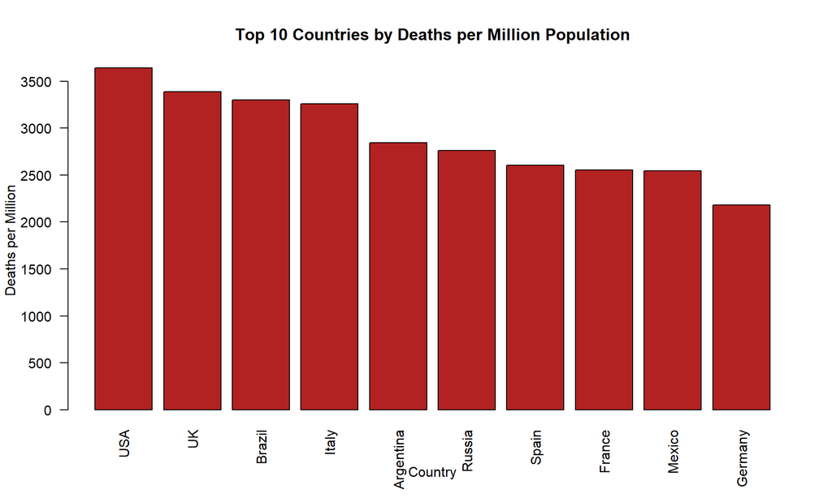

```r
top10_severity <- head(country_data[order(-country_data$Deaths_per_Million), ], 10)

barplot(
  top10_severity$Deaths_per_Million,
  names.arg = top10_severity$Country,
  main = "Top 10 Countries by Deaths per Million Population",
  xlab = "Country",
  ylab = "Deaths per Million",
  col = "firebrick",
  las = 2
)
```

**Code explanation:** Reordering by `Deaths_per_Million` instead of raw totals produces a **completely different ranking** — this is the population-adjusted “how hard was this country actually hit” view.

## 5.5 Bar Chart 3: Global New Cases per Day, by Reporting Period

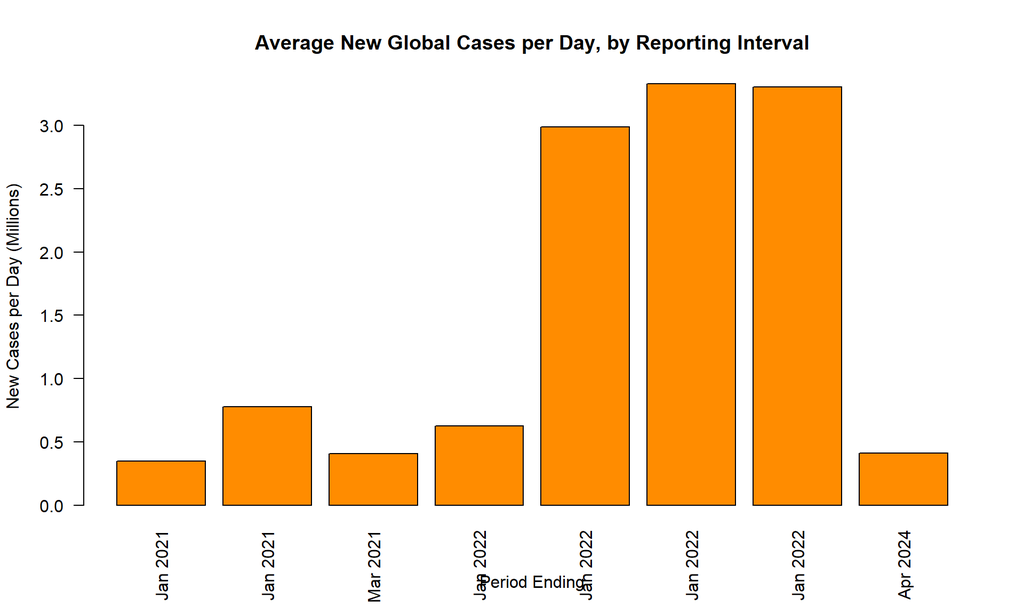

```r
plot_data <- timeline_data[!is.na(timeline_data$New_Cases_per_Day), ]

barplot(
  plot_data$New_Cases_per_Day / 1e6,
  names.arg = format(plot_data$Date, "%b %Y"),
  main = "Average New Global Cases per Day, by Reporting Interval",
  xlab = "Period Ending",
  ylab = "New Cases per Day (Millions)",
  col = "darkorange",
  las = 2
)
```

**Interpretation:** This is the single most revealing chart in the report. Because it standardizes every interval to a **daily rate**, it clearly shows the Omicron wave in January 2022 driving a far higher daily case rate than any other period in this dataset — the pandemic didn’t grow at a steady pace; it arrived in sharp, distinct waves.

## 5.6 Line Plot: Global Cumulative Cases Over Time

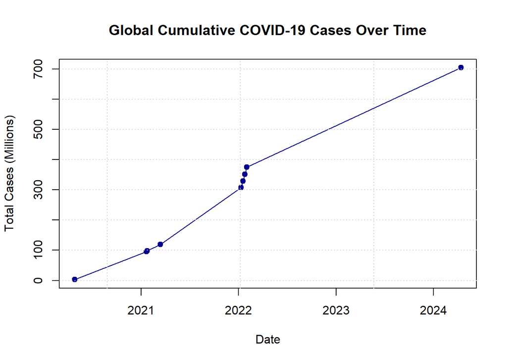

```r
plot(
  timeline_data$Date, timeline_data$Total_Cases / 1e6,
  type = "o", pch = 19, col = "darkblue",
  main = "Global Cumulative COVID-19 Cases Over Time",
  xlab = "Date", ylab = "Total Cases (Millions)"
)
grid()
```

**Code explanation:** `type = "o"` plots points connected by lines. `grid()` adds light gridlines to make the shape of the curve easier to read.

## 5.7 Boxplot: Case Fatality Rate by Continent

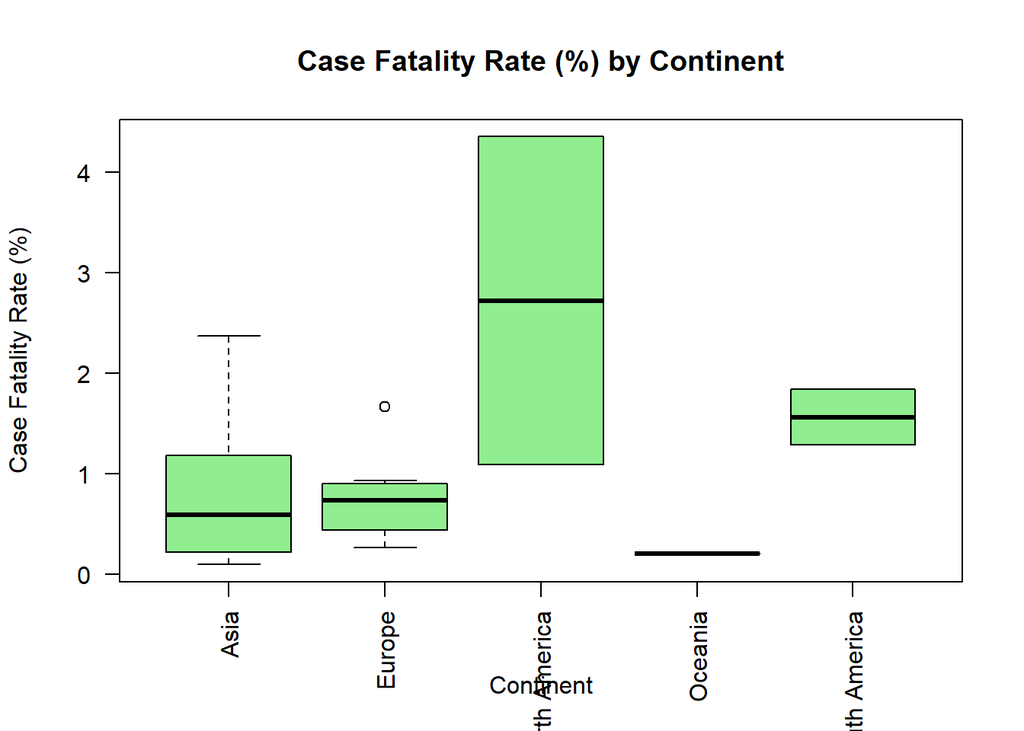

```r
boxplot(
  Case_Fatality_Rate ~ Continent,
  data = country_data,
  main = "Case Fatality Rate (%) by Continent",
  xlab = "Continent",
  ylab = "Case Fatality Rate (%)",
  col = "lightgreen",
  las = 2
)
```

**Interpretation:** This shows the spread (not just the average) of fatality rates within each continent in our sample, including any outlier countries — a boxplot reveals variability that a single average would hide.

## 5.8 Scatter Plot: Cases per Million vs Deaths per Million

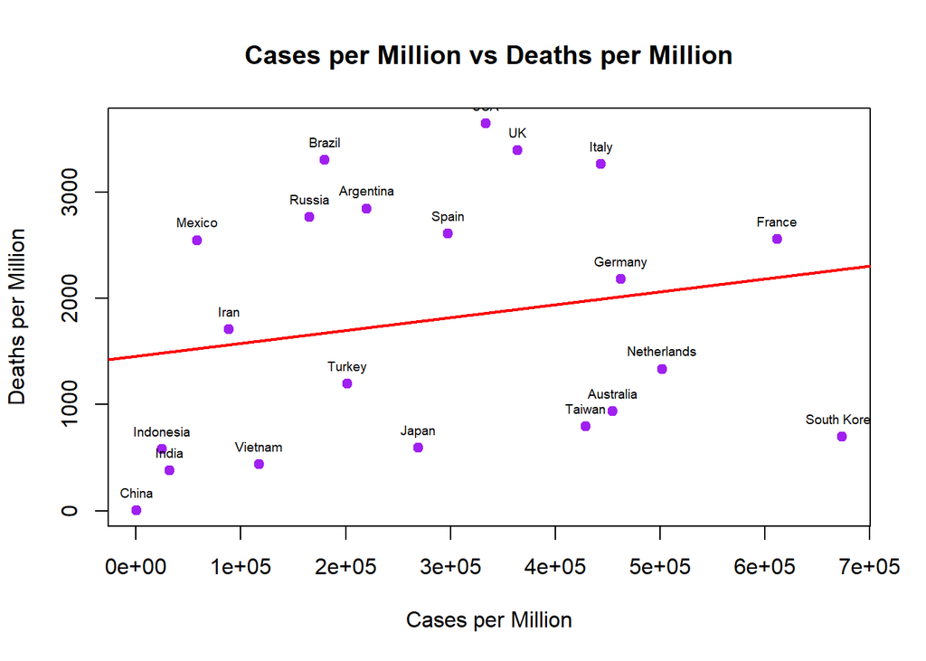

```r
plot(
  country_data$Cases_per_Million, country_data$Deaths_per_Million,
  main = "Cases per Million vs Deaths per Million",
  xlab = "Cases per Million", ylab = "Deaths per Million",
  pch = 19, col = "purple"
)
abline(lm(Deaths_per_Million ~ Cases_per_Million, data = country_data),
       col = "red", lwd = 2)
text(country_data$Cases_per_Million, country_data$Deaths_per_Million,
     labels = country_data$Country, pos = 3, cex = 0.6)
```

**Code explanation:** Each point is one country/territory. `text(..., pos = 3)` labels each point with its country name just above the dot, so individual countries can be identified directly on the scatter plot. `abline(lm(...))` overlays the linear trend line.

**Interpretation:** Countries above the trend line had a worse-than-average death rate relative to how many cases they reported; countries below it (often those with strong testing and healthcare systems) fared relatively better per reported case.

# 6 Findings and Conclusion

This project shows how the exact same R toolkit used for a classroom dataset — `read.csv()`, cleaning, `aggregate()`, `cor()`, pie charts, bar charts, and boxplots — scales up to a genuine global public health question. Working with real, cited figures (rather than invented numbers) surfaced findings that a single headline number never could: that “worst-hit” depends entirely on which metric you ask about, that the pandemic arrived in sharp waves rather than steady growth, and that the data itself carries real limitations that any honest analysis has to name rather than hide.

# 7 R Functions Used — Quick Reference

| Category | Functions Used |
| --- | --- |
| Data Import | `read.csv()` |
| Inspection | `head()`, `str()`, `summary()` |
| Date Handling | `as.Date()`, `format()`, `diff()` |
| Cleaning | `is.na()`, `colSums()`, `order()` |
| Feature Engineering | Arithmetic on vectors, `round()`, `setNames()` |
| Statistics | `mean()`, `sum()`, `cor()`, `aggregate()`, `lm()` |
| Visualization | `pie()`, `barplot()`, `boxplot()`, `plot()`, `abline()`, `text()`, `grid()` |